# Machine Learning 1

Tasnia Sharia (PID A15931128)

10/21/2021

First is clustering methods

# Kmeans clustering

The function in base R to do Kmenas clustering is called ‘kmeans()’

First make up some data where we know what the answer should be:

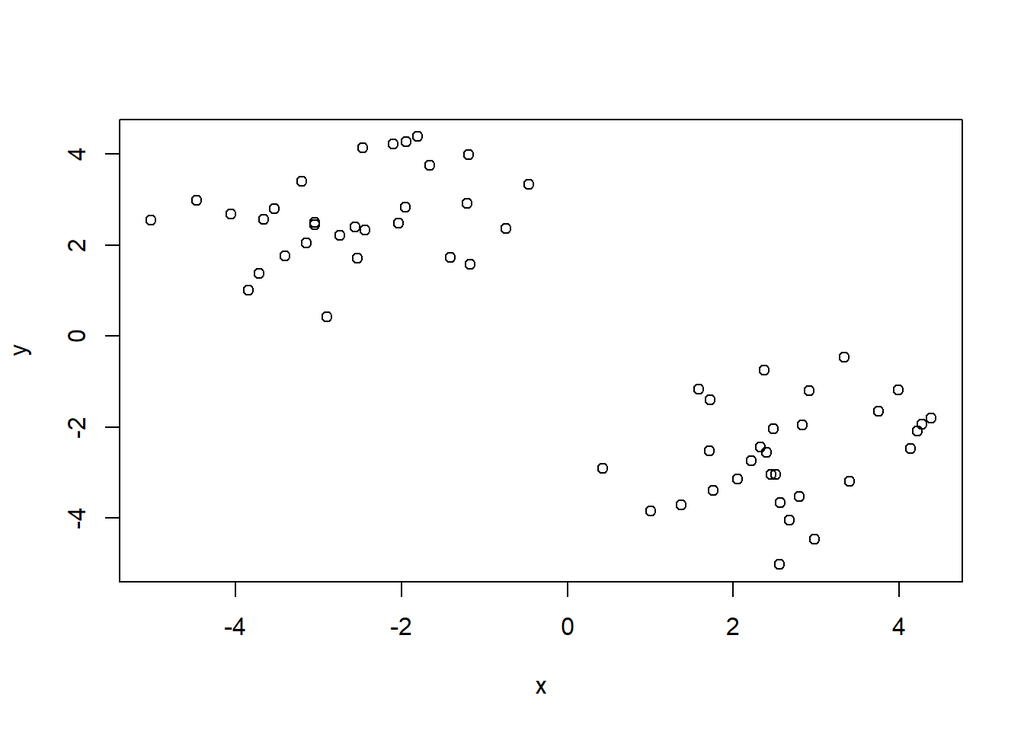

```r
tmp <- c(rnorm(30,-3), rnorm(30,3))
x <- cbind(x=tmp, y=rev(tmp))
plot(x)
```

> Q. Can we use kmeans() to cluster this data setting k to 2 and nstart to 20?

```r
km <- kmeans(x, centers = 2, nstart = 20)
km
```

```
## K-means clustering with 2 clusters of sizes 30, 30
##
## Cluster means:
##           x         y
## 1 -2.583549  2.640275
## 2  2.640275 -2.583549
##
## Clustering vector:
##  [1] 1 1 1 1 1 1 1 1 1 1 1 1 1 1 1 1 1 1 1 1 1 1 1 1 1 1 1 1 1 1 2 2 2 2 2 2 2 2
## [39] 2 2 2 2 2 2 2 2 2 2 2 2 2 2 2 2 2 2 2 2 2 2
##
## Within cluster sum of squares by cluster:
## [1] 64.95757 64.95757
##  (between_SS / total_SS =  86.3 %)
##
## Available components:
##
## [1] "cluster"      "centers"      "totss"        "withinss"     "tot.withinss"
## [6] "betweenss"    "size"         "iter"         "ifault"
```

> Q. How many points are in each cluster?

```r
km$size
```

```
## [1] 30 30
```

> Q. What ‘component’ of your result object details cluster assignment/membership?

```r
km$cluster
```

```
##  [1] 1 1 1 1 1 1 1 1 1 1 1 1 1 1 1 1 1 1 1 1 1 1 1 1 1 1 1 1 1 1 2 2 2 2 2 2 2 2
## [39] 2 2 2 2 2 2 2 2 2 2 2 2 2 2 2 2 2 2 2 2 2 2
```

> Q. What ‘component’ of your result object details cluster center?

```r
km$centers
```

```
##           x         y
## 1 -2.583549  2.640275
## 2  2.640275 -2.583549
```

> Q. Plot x colored by the kmeans cluster assignment and and cluster centers as blue points

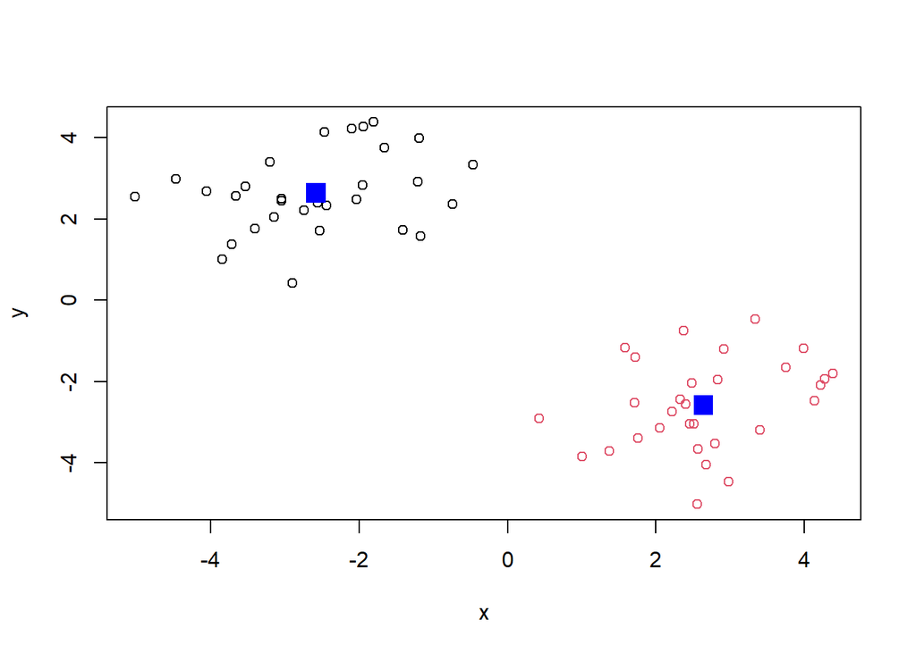

```r
plot(x, col=km$cluster)
points(km$centers, col="blue", pch=15, cex=2)
```

# Hierarchical Clustering

A big limitation with k-means is that we have to tell it K (the number of clusters we want).

Analyze this same data with hclust()

Demonstrate the use of dist(), hclust(), plot(), and cutree() function to do clustering. Generate dendeograms and return cluster assignment membership vector.

```r
hc <- hclust( dist(x) )
hc
```

```
##
## Call:
## hclust(d = dist(x))
##
## Cluster method   : complete
## Distance         : euclidean
## Number of objects: 60
```

There is a plot method for hclust result objects. Let’s see it.

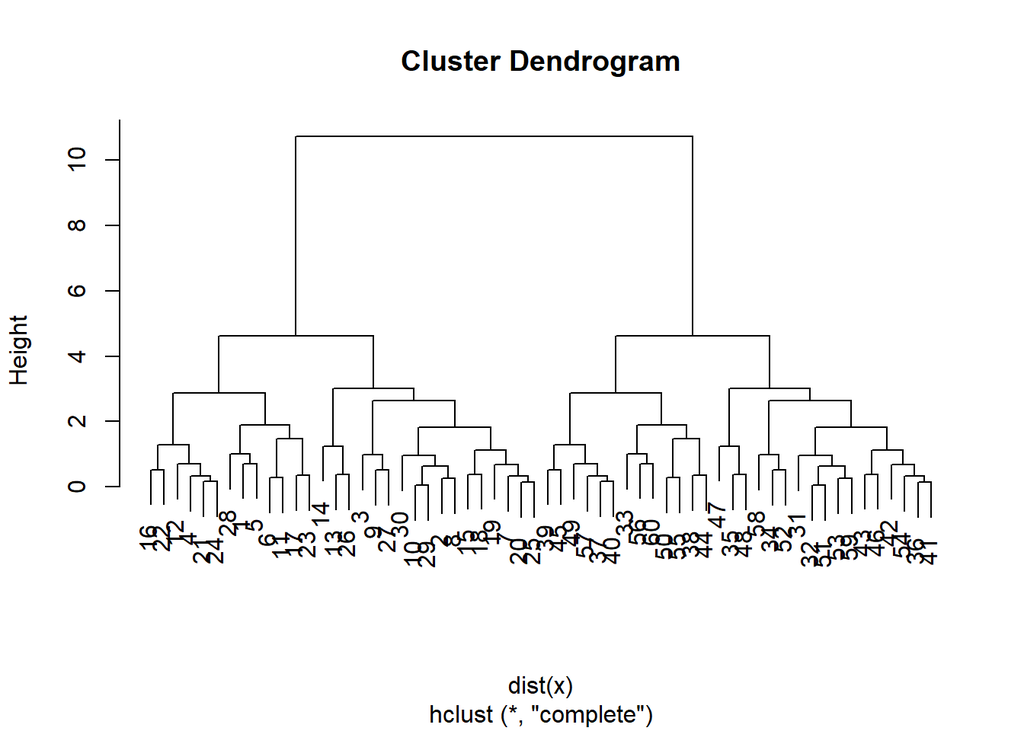

```r
plot(hc)
```

To get our cluster membership vector we have to do a wee bit more work. We have to “cut” the tree where we think it makes sense. For this we use the ‘cutree()’ function.

```r
cutree(hc, h=8)
```

```
##  [1] 1 1 1 1 1 1 1 1 1 1 1 1 1 1 1 1 1 1 1 1 1 1 1 1 1 1 1 1 1 1 2 2 2 2 2 2 2 2
## [39] 2 2 2 2 2 2 2 2 2 2 2 2 2 2 2 2 2 2 2 2 2 2
```

You can also call ‘cutree()’ settng k= the number of grps/clusters you want

```r
grps <- cutree(hc, k=2)
```

Make our results plot

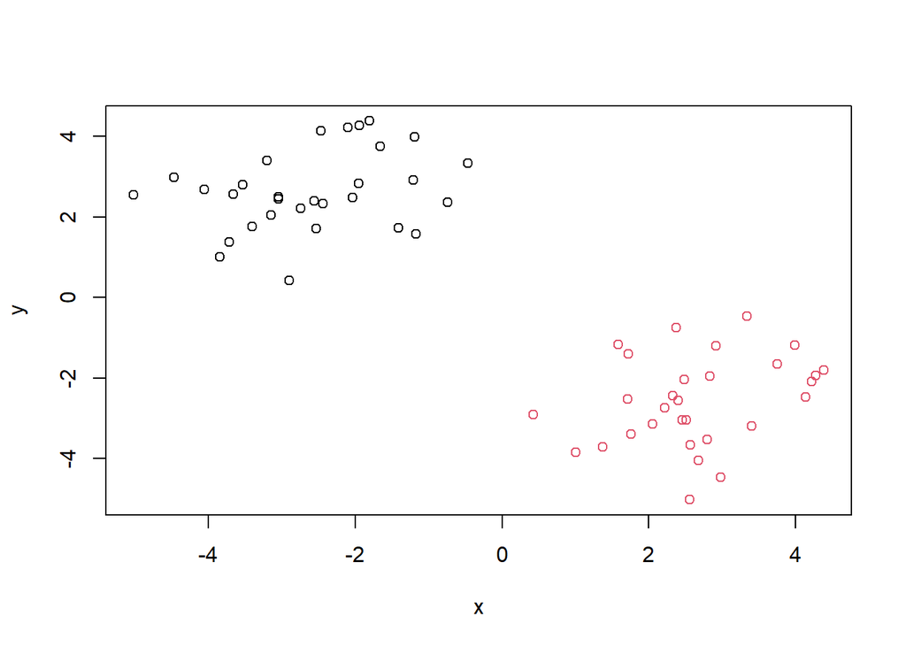

```r
plot(x, col=grps)
```

We will examine the PCA of UK food data

```r
url <- "https://tinyurl.com/UK-foods"
x <- read.csv(url)
View(x)
```

> **Q1.** How many rows and columns are in your new data frame named x? What R functions could you use to answer this questions?

```r
nrow(x)
```

```
## [1] 17
```

```r
ncol(x)
```

```
## [1] 5
```

```r
dim(x)
```

```
## [1] 17  5
```

# The dim() function returns the # of rows and columns. Using nrow() or ncol() functions also provide the answer

```r
## Preview the first 6 rows
head(x)
```

```
##                X England Wales Scotland N.Ireland
## 1         Cheese     105   103      103        66
## 2  Carcass_meat      245   227      242       267
## 3    Other_meat      685   803      750       586
## 4           Fish     147   160      122        93
## 5 Fats_and_oils      193   235      184       209
## 6         Sugars     156   175      147       139
```

```r
## Preview the last 6 rows
tail(x)
```

```
##                    X England Wales Scotland N.Ireland
## 12      Fresh_fruit     1102  1137      957       674
## 13          Cereals     1472  1582     1462      1494
## 14         Beverages      57    73       53        47
## 15      Soft_drinks     1374  1256     1572      1506
## 16 Alcoholic_drinks      375   475      458       135
## 17    Confectionery       54    64       62        41
```

The data should be 17 by 4 dimensions. There is an extra first column that needs to be fixed.

```r
# Note how the minus indexing works
rownames(x) <- x[,1]
x <- x[,-1]
head(x)
```

```
##                England Wales Scotland N.Ireland
## Cheese             105   103      103        66
## Carcass_meat       245   227      242       267
## Other_meat         685   803      750       586
## Fish               147   160      122        93
## Fats_and_oils      193   235      184       209
## Sugars             156   175      147       139
```

Now let’s check the dimensions again

```r
dim(x)
```

```
## [1] 17  4
```

Alternative approach to setting the correct row-names

```r
x <- read.csv(url, row.names=1)
head(x)
```

```
##                England Wales Scotland N.Ireland
## Cheese             105   103      103        66
## Carcass_meat       245   227      242       267
## Other_meat         685   803      750       586
## Fish               147   160      122        93
## Fats_and_oils      193   235      184       209
## Sugars             156   175      147       139
```

```r
dim(x)
```

```
## [1] 17  4
```

> **Q2.** Which approach to solving the ‘row-names problem’ mentioned above do you prefer and why? Is one approach more robust than another under certain circumstances?

The second approach to solving the ‘row-names problem’ where we include the row.names argument is more convenient.

```r
# What would happened if we ran row names(x) <- x[,1] again
rownames(x) <- x[,1]
head(x)
```

```
##     England Wales Scotland N.Ireland
## 105     105   103      103        66
## 245     245   227      242       267
## 685     685   803      750       586
## 147     147   160      122        93
## 193     193   235      184       209
## 156     156   175      147       139
```

Now we go back to the original data with the right number of dimensions and correct headings.

```r
x <- read.csv(url, row.names=1)
head(x)
```

```
##                England Wales Scotland N.Ireland
## Cheese             105   103      103        66
## Carcass_meat       245   227      242       267
## Other_meat         685   803      750       586
## Fish               147   160      122        93
## Fats_and_oils      193   235      184       209
## Sugars             156   175      147       139
```

```r
View(x)
```

we will spot major differences and trends by generating boxplots and various pairwise plots that may not help as much

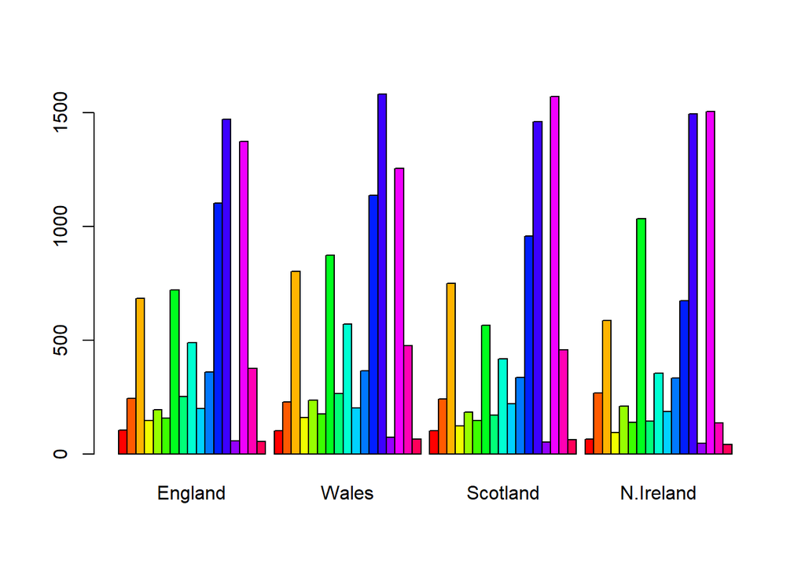

```r
barplot(as.matrix(x), beside=T, col=rainbow(nrow(x)))
```

> **Q3:** Changing what optional argument in the above barplot() function results in the following plot?

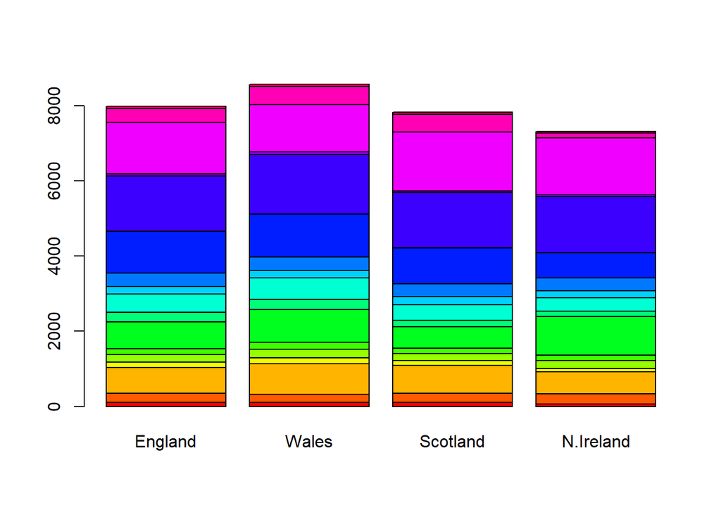

```r
barplot(as.matrix(x), beside=FALSE, col=rainbow(nrow(x)))
```

Setting beside argument to FALSE creates a stacked boxplot. Leaving the beside argument out would also give the same result because being FALSE is the default. If beside=TRUE were to be added, TRUE would be a numeric vector and includes other components that could be usedul information to the data.

> **Q5:** Generating all pairwise plots may help somewhat. Can you make sense of the following code and resulting figure? What does it mean if a given point lies on the diagonal for a given plot?

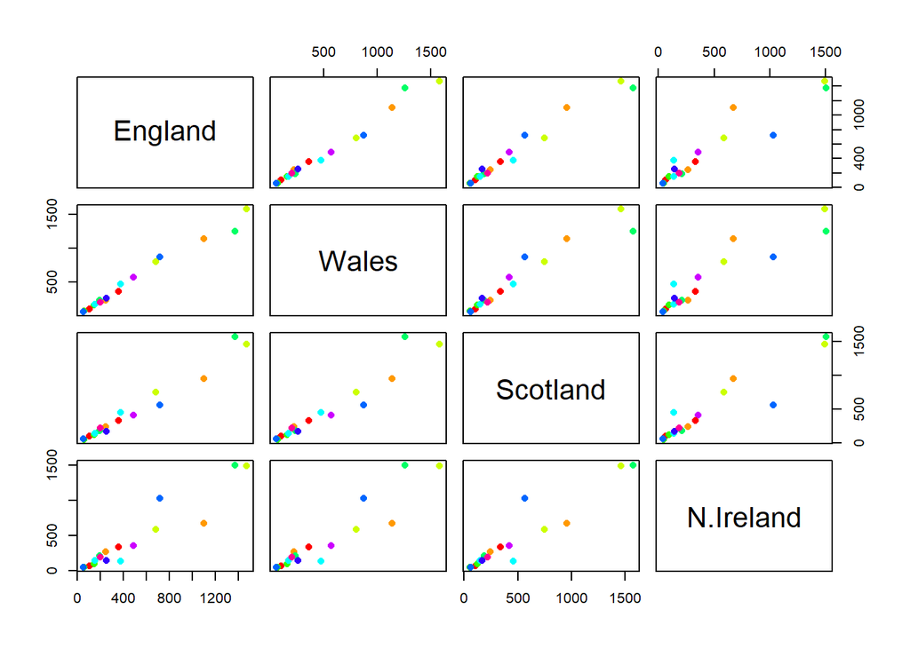

```r
pairs(x, col=rainbow(10), pch=16)
```